# HD-CNN con modelo base ResNet-50 (Conjunto de datos reducido)

En primer lugar, importamos las librerías necesarias para ejecutar este cuaderno.

```python
from fastai.vision.all import *
```

Definimos la ruta que contiene las imágenes del conjunto de datos.

```python
path = Path('/home/user/images')
```

Listamos el directorio establecido para mostrar las carpetas por clase que contienen dicho directorio.

```python
path.ls()
```

```
(#144) [Path('/home/user/images/Chromis margaritifer'),Path('/home/user/images/Abudefduf sordidus'),Path('/home/user/images/Scardinius erythrophthalmus'),Path('/home/user/images/Chromis ternatensis'),Path('/home/user/images/Stegastes nigricans'),Path('/home/user/images/Lepomis peltastes'),Path('/hom…
```

Definimos la ruta padre del proyecto donde se encuentran los datos.

```python
df_path = Path('/home/user/')
```

Cargamos el archivo CSV en forma de *dataframe* de Pandas con las clases jerárquicas de cada imagen, la ruta de la imagen y si corresponde o no al conjunto de validación.

```python
df = pd.read_csv(df_path/"csv/families3-stratified.csv")
```

Cargamos los pesos en forma de *dataframes* de las clases para corregir el desbalanceo durante el entrenamiento.

```python
weights_df = pd.read_csv(df_path/'csv/families3-weights.csv')
weights_family_df = pd.read_csv(df_path/'csv/families3-weights-family.csv')
```

Mostramos, como ejemplo, el *dataframe* de los pesos por clase final.

```python
weights_df
```

|  | Specie | Count | Weight |
| --- | --- | --- | --- |
| 0 | Abramis brama | 300 | 1.999722 |
| 1 | Abudefduf abdominalis | 177 | 3.389360 |
| 2 | Abudefduf bengalensis | 299 | 2.006410 |
| 3 | Abudefduf saxatilis | 1423 | 0.421586 |
| 4 | Abudefduf septemfasciatus | 128 | 4.686849 |
| ... | ... | ... | ... |
| 139 | Stegastes partitus | 174 | 3.447797 |
| 140 | Stegastes planifrons | 178 | 3.370318 |
| 141 | Systomus rubripinnis | 587 | 1.022005 |
| 142 | Telestes muticellus | 144 | 4.166088 |
| 143 | Tinca tinca | 246 | 2.438686 |

144 rows × 3 columns

```python
n_classes = len(set(df['Specie']))
```

Creamos el cuerpo y cabeza del modelo tomando como base ResNet-50 con pesos preentrenados.

```python
model = resnet50
body = create_body(model, cut=-2)
body
```

```
Downloading: "https://download.pytorch.org/models/resnet50-19c8e357.pth" to /home/user/.cache/torch/hub/checkpoints/resnet50-19c8e357.pth
```

```
Sequential(
  (0): Conv2d(3, 64, kernel_size=(7, 7), stride=(2, 2), padding=(3, 3), bias=False)
  (1): BatchNorm2d(64, eps=1e-05, momentum=0.1, affine=True, track_running_stats=True)
  (2): ReLU(inplace=True)
  (3): MaxPool2d(kernel_size=3, stride=2, padding=1, dilation=1, ceil_mode=False)
  (4): Sequential(
    (0): Bottleneck(
      (conv1): Conv2d(64, 64, kernel_size=(1, 1), stride=(1, 1), bias=False)
      (bn1): BatchNorm2d(64, eps=1e-05, momentum=0.1, affine=True, track_running_stats=True)
      (conv2): Conv2d(64, 64, kernel_size=(3, 3), stride=(1, 1), padding=(1, 1), bias=False)
      (bn2): BatchNorm2d(64, eps=1e-05, momentum=0.1, affine=True, track_running_stats=True)
      (conv3): Conv2d(64, 256, kernel_size=(1, 1), stride=(1, 1), bias=False)
      (bn3): BatchNorm2d(256, eps=1e-05, momentum=0.1, affine=True, track_running_stats=True)
      (relu): ReLU(inplace=True)
      (downsample): Sequential(
        (0): Conv2d(64, 256, kernel_size=(1, 1), stride=(1, 1), bias=False)
        (1): BatchNorm2d(256, eps=1e-05, momentum=0.1, affine=True, track_running_stats=True)
      )
    )
    (1): Bottleneck(
      (conv1): Conv2d(256, 64, kernel_size=(1, 1), stride=(1, 1), bias=False)
      (bn1): BatchNorm2d(64, eps=1e-05, momentum=0.1, affine=True, track_running_stats=True)
      (conv2): Conv2d(64, 64, kernel_size=(3, 3), stride=(1, 1), padding=(1, 1), bias=False)
      (bn2): BatchNorm2d(64, eps=1e-05, momentum=0.1, affine=True, track_running_stats=True)
      (conv3): Conv2d(64, 256, kernel_size=(1, 1), stride=(1, 1), bias=False)
      (bn3): BatchNorm2d(256, eps=1e-05, momentum=0.1, affine=True, track_running_stats=True)
      (relu): ReLU(inplace=True)
    )
    (2): Bottleneck(
      (conv1): Conv2d(256, 64, kernel_size=(1, 1), stride=(1, 1), bias=False)
      (bn1): BatchNorm2d(64, eps=1e-05, momentum=0.1, affine=True, track_running_stats=True)
      (conv2): Conv2d(64, 64, kernel_size=(3, 3), stride=(1, 1), padding=(1, 1), bias=False)
      (bn2): BatchNorm2d(64, eps=1e-05, momentum=0.1, affine=True, track_running_stats=True)
      (conv3): Conv2d(64, 256, kernel_size=(1, 1), stride=(1, 1), bias=False)
      (bn3): BatchNorm2d(256, eps=1e-05, momentum=0.1, affine=True, track_running_stats=True)
      (relu): ReLU(inplace=True)
    )
  )
  (5): Sequential(
    (0): Bottleneck(
```

[output cut: 119 more lines]

```
      (conv3): Conv2d(512, 2048, kernel_size=(1, 1), stride=(1, 1), bias=False)
      (bn3): BatchNorm2d(2048, eps=1e-05, momentum=0.1, affine=True, track_running_stats=True)
      (relu): ReLU(inplace=True)
    )
    (2): Bottleneck(
      (conv1): Conv2d(2048, 512, kernel_size=(1, 1), stride=(1, 1), bias=False)
      (bn1): BatchNorm2d(512, eps=1e-05, momentum=0.1, affine=True, track_running_stats=True)
      (conv2): Conv2d(512, 512, kernel_size=(3, 3), stride=(1, 1), padding=(1, 1), bias=False)
      (bn2): BatchNorm2d(512, eps=1e-05, momentum=0.1, affine=True, track_running_stats=True)
      (conv3): Conv2d(512, 2048, kernel_size=(1, 1), stride=(1, 1), bias=False)
      (bn3): BatchNorm2d(2048, eps=1e-05, momentum=0.1, affine=True, track_running_stats=True)
      (relu): ReLU(inplace=True)
    )
  )
)
```

```python
stem = body[0:4]
stem
```

```
Sequential(
  (0): Conv2d(3, 64, kernel_size=(7, 7), stride=(2, 2), padding=(3, 3), bias=False)
  (1): BatchNorm2d(64, eps=1e-05, momentum=0.1, affine=True, track_running_stats=True)
  (2): ReLU(inplace=True)
  (3): MaxPool2d(kernel_size=3, stride=2, padding=1, dilation=1, ceil_mode=False)
)
```

Separamos el cuerpo de la arquitectura en los distintos bloques para definir cada uno de ellos y aplicar posteriormente la arquitectura HD-CNN.

```python
block1, block2, block3, block4 = body[4], body[5], body[6], body[7]
block1
```

```
Sequential(
  (0): Bottleneck(
    (conv1): Conv2d(64, 64, kernel_size=(1, 1), stride=(1, 1), bias=False)
    (bn1): BatchNorm2d(64, eps=1e-05, momentum=0.1, affine=True, track_running_stats=True)
    (conv2): Conv2d(64, 64, kernel_size=(3, 3), stride=(1, 1), padding=(1, 1), bias=False)
    (bn2): BatchNorm2d(64, eps=1e-05, momentum=0.1, affine=True, track_running_stats=True)
    (conv3): Conv2d(64, 256, kernel_size=(1, 1), stride=(1, 1), bias=False)
    (bn3): BatchNorm2d(256, eps=1e-05, momentum=0.1, affine=True, track_running_stats=True)
    (relu): ReLU(inplace=True)
    (downsample): Sequential(
      (0): Conv2d(64, 256, kernel_size=(1, 1), stride=(1, 1), bias=False)
      (1): BatchNorm2d(256, eps=1e-05, momentum=0.1, affine=True, track_running_stats=True)
    )
  )
  (1): Bottleneck(
    (conv1): Conv2d(256, 64, kernel_size=(1, 1), stride=(1, 1), bias=False)
    (bn1): BatchNorm2d(64, eps=1e-05, momentum=0.1, affine=True, track_running_stats=True)
    (conv2): Conv2d(64, 64, kernel_size=(3, 3), stride=(1, 1), padding=(1, 1), bias=False)
    (bn2): BatchNorm2d(64, eps=1e-05, momentum=0.1, affine=True, track_running_stats=True)
    (conv3): Conv2d(64, 256, kernel_size=(1, 1), stride=(1, 1), bias=False)
    (bn3): BatchNorm2d(256, eps=1e-05, momentum=0.1, affine=True, track_running_stats=True)
    (relu): ReLU(inplace=True)
  )
  (2): Bottleneck(
    (conv1): Conv2d(256, 64, kernel_size=(1, 1), stride=(1, 1), bias=False)
    (bn1): BatchNorm2d(64, eps=1e-05, momentum=0.1, affine=True, track_running_stats=True)
    (conv2): Conv2d(64, 64, kernel_size=(3, 3), stride=(1, 1), padding=(1, 1), bias=False)
    (bn2): BatchNorm2d(64, eps=1e-05, momentum=0.1, affine=True, track_running_stats=True)
    (conv3): Conv2d(64, 256, kernel_size=(1, 1), stride=(1, 1), bias=False)
    (bn3): BatchNorm2d(256, eps=1e-05, momentum=0.1, affine=True, track_running_stats=True)
    (relu): ReLU(inplace=True)
  )
)
```

```python
head = create_head(2048*2,n_classes)
head
```

```
Sequential(
  (0): AdaptiveConcatPool2d(
    (ap): AdaptiveAvgPool2d(output_size=1)
    (mp): AdaptiveMaxPool2d(output_size=1)
  )
  (1): Flatten(full=False)
  (2): BatchNorm1d(4096, eps=1e-05, momentum=0.1, affine=True, track_running_stats=True)
  (3): Dropout(p=0.25, inplace=False)
  (4): Linear(in_features=4096, out_features=512, bias=False)
  (5): ReLU(inplace=True)
  (6): BatchNorm1d(512, eps=1e-05, momentum=0.1, affine=True, track_running_stats=True)
  (7): Dropout(p=0.5, inplace=False)
  (8): Linear(in_features=512, out_features=144, bias=False)
)
```

Definimos una función para obtener las etiquetas de cada ejemplo, en este caso: familia y especie.

```python
def custom_get_y(o):
    fine_label = o['Specie']
    coarse1_label = o['Family']
    return [coarse1_label, fine_label]
```

```python
def count_classes_per_coarse(labels_df):
    result = {}
    for c in set(labels_df['coarse']):
        classes_with_c = labels_df[labels_df['coarse']==c]
        result[c] = len(classes_with_c)
    return result
```

```python
labels_df = pd.DataFrame.from_dict({'fine': df['Specie'].values, 'coarse': df['Family'].values})
labels_df
```

|  | fine | coarse |
| --- | --- | --- |
| 0 | Hypophthalmichthys molitrix | Cyprinidae |
| 1 | Dascyllus trimaculatus | Pomacentridae |
| 2 | Micropterus dolomieu | Centrarchidae |
| 3 | Cyprinus carpio | Cyprinidae |
| 4 | Abudefduf sordidus | Pomacentridae |
| ... | ... | ... |
| 86383 | Pseudorasbora parva | Cyprinidae |
| 86384 | Parazacco spilurus | Cyprinidae |
| 86385 | Micropterus salmoides | Centrarchidae |
| 86386 | Lepomis macrochirus | Centrarchidae |
| 86387 | Abudefduf vaigiensis | Pomacentridae |

86388 rows × 2 columns

```python
classes_per_coarse = count_classes_per_coarse(labels_df)
classes_per_coarse
```

```
{'Pomacentridae': 19638, 'Centrarchidae': 38554, 'Cyprinidae': 28196}
```

```python
class Resnet50CustomModel(Module):
    def __init__(self, model, classes_per_coarse):
        n_coarse_classes = len(classes_per_coarse.keys())
        self.shared_layers = create_body(model, cut=-2)[:6]
        self.coarse_component = create_body(model, cut=-2)[6:]
        self.coarse_head = create_head(2048*2,n_coarse_classes)
        self.fine_components = nn.ModuleList([create_body(model, cut=-2)[6:] for _ in range(n_coarse_classes)])
        self.fine_heads = nn.ModuleList([create_head(2048*2, 144) for num_classes in classes_per_coarse.values()])


    def forward(self, x):
        x = self.shared_layers(x)
        coarse_x = self.coarse_component(x)
        coarse1_label = self.coarse_head(coarse_x)
        coarse_idx = coarse1_label[0].argmax()
        x = self.fine_components[coarse_idx](x)
        fine_label = self.fine_heads[coarse_idx](x)
        return {
            'fine_label': fine_label,
            'coarse1_label': coarse1_label
        }
```

Creamos el modelo con la clase definida pasándole la arquitectura base y la información sobre las dimensiones.

```python
model = Resnet50CustomModel(resnet50, classes_per_coarse)
```

Como hemos modificado el modelo y la obtención de las clases para usar una salida múltiple, tenemos que modificar el tipo de bloque de categoría a uno que soporte estas salidas. Para ello, definimos una función que obtenga la clase y codifique a categoría cada una.

```python
class CustomCategorize(DisplayedTransform):
    "Reversible transform of category string to `vocab` id"
    loss_func,order=CrossEntropyLossFlat(),1
    def __init__(self, vocab=None, vocab_coarse1=None, vocab_coarse2=None, sort=True, add_na=False, num_y=1):
        store_attr()
        self.vocab = None if vocab is None else CategoryMap(vocab, sort=sort, add_na=add_na)
        self.vocab_coarse1 = None if vocab_coarse1 is None else CategoryMap(vocab_coarse1, sort=sort, add_na=add_na)

    def setups(self, dsets):
        fine_dsets = [d[1] for d in dsets]
        coarse1_dsets = [d[0] for d in dsets]
        if self.vocab is None and dsets is not None: self.vocab = CategoryMap(fine_dsets, sort=self.sort, add_na=self.add_na)
        if self.vocab_coarse1 is None and dsets is not None: self.vocab_coarse1 = CategoryMap(coarse1_dsets, sort=self.sort, add_na=self.add_na)
        self.c = len(self.vocab)

    def encodes(self, o): return {'fine_label': TensorCategory(self.vocab.o2i[o[1]]),
                                  'coarse1_label': TensorCategory(self.vocab_coarse1.o2i[o[0]])
                                 }
    def decodes(self, o): return Category      (self.vocab    [o])
```

```python
def CustomCategoryBlock(vocab=None, sort=True, add_na=False, num_y=1):
    "`TransformBlock` for single-label categorical targets"
    return TransformBlock(type_tfms=CustomCategorize(vocab=vocab, sort=sort, add_na=add_na))
```

Creamos un *splitter* personalizado con los parámetros de cada bloque y del *head*.

```python
def custom_splitter(model):
    return [params(model.shared_layers),
            params(model.coarse_component),
            params(model.fine_components),
            params(model.coarse_head),
            params(model.fine_heads)]
```

Creamos un *datablock* con: bloques de tipo imagen y categoría personalizada *CustomCategoryBlock*, un separador por columna, la *x* con la columna que contienen la ruta de las imágenes, la *y* con la función personalizada, una transformación para hacer un recorte aleatorio dejando un tamaño común de 336x336, y las transformaciones de aumento de datos por defecto.

```python
fishes = DataBlock(blocks = (ImageBlock, CustomCategoryBlock),
                 splitter=ColSplitter(),
                 get_x = ColReader(5, pref=path),
                 get_y=custom_get_y,
                 item_tfms=RandomResizedCrop(336, min_scale=0.5),
                 batch_tfms=aug_transforms())
dls = fishes.dataloaders(df)
```

Mostramos los *dataloaders* generados con el *datablock*.

```python
dls.train_ds, dls.valid_ds
```

```
((#69110) [(PILImage mode=RGB size=768x1024, {'fine_label': TensorCategory(62), 'coarse1_label': TensorCategory(1)}),(PILImage mode=RGB size=1024x768, {'fine_label': TensorCategory(58), 'coarse1_label': TensorCategory(2)}),(PILImage mode=RGB size=768x1024, {'fine_label': TensorCategory(79), 'coarse1…
 (#17278) [(PILImage mode=RGB size=1024x768, {'fine_label': TensorCategory(92), 'coarse1_label': TensorCategory(1)}),(PILImage mode=RGB size=768x1024, {'fine_label': TensorCategory(117), 'coarse1_label': TensorCategory(0)}),(PILImage mode=RGB size=1024x768, {'fine_label': TensorCategory(83), 'coarse…
```

Creamos el tensor con los pesos por clase y lo pasamos a GPU para poder usarlo durante el entrenamiento.

```python
weights = tensor([float(weights_df[weights_df['Specie']==c]['Weight']) for c in dls.vocab]).cuda()
weights_family = tensor([float(weights_family_df[weights_family_df['Family']==c]['Weight']) for c in dls.vocab_coarse1]).cuda()
```

Defimos nuestra función de pérdida como el sumatorio de la pérdida en entropía cruzada de las dos salidas.

```python
def loss_func(out, targ):
    return nn.CrossEntropyLoss(weight=weights)(out['fine_label'], targ['fine_label']) + \
            nn.CrossEntropyLoss(weight=weights_family)(out['coarse1_label'], targ['coarse1_label'])
```

Defimos la función de accuracy con la etiqueta fina, ya que es el resultado final que nos interesa. Además, esta etiqueta fue la que se usó para definir las particiones estratificadas, por lo que es la única que se debería tener en cuenta si queremos resultados más fiables.

```python
def custom_accuracy(inp, targ, axis=-1):
    pred1,targ1 = flatten_check(inp['fine_label'].argmax(dim=axis), targ['fine_label'])
    acc1 = (pred1 == targ1).float().mean()
    return acc1
```

Creamos nuestro objeto *Learner* con los *dataloaders*, la función de pérdida _loss*func* creada, la métrica exactitud y el *splitter* creado. Además, congelamos nuestro modelo para ajustar primero los pesos preentrenados a nuestras clases.

```python
learn = Learner(dls, model, loss_func=loss_func, metrics=custom_accuracy,
                   splitter=custom_splitter).to_fp16()
learn.freeze()
```

Mostramos un resumen de nuestro modelo.

```python
learn.summary()
```

| epoch | train_loss | valid_loss | custom_accuracy | time |
| --- | --- | --- | --- | --- |
| 0 | None | None | 00:00 |  |

```
Resnet50CustomModel (Input shape: ['64 x 3 x 336 x 336'])
================================================================
Layer (type)         Output Shape         Param #    Trainable
================================================================
Conv2d               64 x 64 x 168 x 168  9,408      False
________________________________________________________________
BatchNorm2d          64 x 64 x 168 x 168  128        True
________________________________________________________________
ReLU                 64 x 64 x 168 x 168  0          False
________________________________________________________________
MaxPool2d            64 x 64 x 84 x 84    0          False
________________________________________________________________
Conv2d               64 x 64 x 84 x 84    4,096      False
________________________________________________________________
BatchNorm2d          64 x 64 x 84 x 84    128        True
________________________________________________________________
Conv2d               64 x 64 x 84 x 84    36,864     False
________________________________________________________________
BatchNorm2d          64 x 64 x 84 x 84    128        True
________________________________________________________________
Conv2d               64 x 256 x 84 x 84   16,384     False
________________________________________________________________
BatchNorm2d          64 x 256 x 84 x 84   512        True
________________________________________________________________
ReLU                 64 x 256 x 84 x 84   0          False
________________________________________________________________
Conv2d               64 x 256 x 84 x 84   16,384     False
________________________________________________________________
BatchNorm2d          64 x 256 x 84 x 84   512        True
________________________________________________________________
Conv2d               64 x 64 x 84 x 84    16,384     False
________________________________________________________________
BatchNorm2d          64 x 64 x 84 x 84    128        True
________________________________________________________________
Conv2d               64 x 64 x 84 x 84    36,864     False
________________________________________________________________
BatchNorm2d          64 x 64 x 84 x 84    128        True
________________________________________________________________
Conv2d               64 x 256 x 84 x 84   16,384     False
________________________________________________________________
```

[output cut: 387 more lines]

```
Total params: 49,859,136
Total trainable params: 2,285,440
Total non-trainable params: 47,573,696

Optimizer used: <function Adam at 0x7fd2e7ffa670>
Loss function: <function loss_func at 0x7fd2e1e239d0>

Model frozen up to parameter group #4

Callbacks:
  - ModelToHalf
  - TrainEvalCallback
  - Recorder
  - ProgressCallback
  - MixedPrecision
```

Entrenamos el modelo congelado para ajustar los pesos de las últimas capas a nuestras clases, y descongelamos el modelo.

```python
learn.fit(1, 3e-3)
```

| epoch | train_loss | valid_loss | custom_accuracy | time |
| --- | --- | --- | --- | --- |
| 0 | 3.796122 | 3.595421 | 0.231856 | 10:48 |

```python
learn.save('species144-hdcnn-resnet50-fepochs1-uepochs0')
```

```
Path('models/species144-hdcnn-resnet50-fepochs1-uepochs0.pth')
```

Defimos una función para continuar el aprendizaje con los pesos guardados.

```python
def continue_training(pth_filename):
    learn = Learner(dls, model, loss_func=loss_func, metrics=custom_accuracy,
                   splitter=custom_splitter).to_fp16()
    learn.load(pth_filename)
    learn.unfreeze()
    return learn
```

```python
learn.unfreeze()
```

Buscamos el factor de aprendizaje más adecuado con lr_find.

```
SuggestedLRs(lr_min=7.585775847473997e-08, lr_steep=6.309573450380412e-07)
```

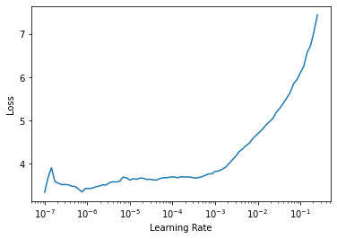

```python
learn.lr_find()
```

Entrenamos durante 10 épocas con el factor de aprendizaje máximo adecuado según la visualización del buscador de factores de aprendizaje.

```python
learn.fit(10, slice(1e-6,1e-4))
```

| epoch | train_loss | valid_loss | custom_accuracy | time |
| --- | --- | --- | --- | --- |
| 0 | 2.884595 | 2.562476 | 0.363699 | 09:46 |
| 1 | 2.569497 | 2.317070 | 0.412085 | 09:46 |
| 2 | 2.409003 | 2.143274 | 0.444380 | 09:48 |
| 3 | 2.252832 | 2.005813 | 0.472219 | 09:56 |
| 4 | 2.127790 | 1.925118 | 0.490624 | 09:51 |
| 5 | 1.963641 | 1.828566 | 0.506482 | 09:43 |
| 6 | 1.910445 | 1.772728 | 0.514585 | 09:41 |
| 7 | 1.813891 | 1.724164 | 0.529865 | 09:48 |
| 8 | 1.755272 | 1.651296 | 0.534379 | 09:41 |
| 9 | 1.716195 | 1.612779 | 0.553478 | 09:42 |

```python
learn.save('species144-hdcnn-resnet50-fepochs1-uepochs10')
```

```
Path('models/species144-hdcnn-resnet50-fepochs1-uepochs10.pth')
```

```python
learn = continue_training('species144-hdcnn-resnet50-fepochs1-uepochs10')
```

Continuamos entrenando nuestro modelo hasta las 50 épocas, guardando los pesos del entrenamiento en cada 10 épocas.

```python
learn.fit(10, slice(1e-6,1e-4))
learn.save('species144-hdcnn-resnet50-fepochs1-uepochs20')
```

| epoch | train_loss | valid_loss | custom_accuracy | time |
| --- | --- | --- | --- | --- |
| 0 | 1.587296 | 1.574409 | 0.558340 | 09:46 |
| 1 | 1.586948 | 1.537217 | 0.560829 | 09:45 |
| 2 | 1.524251 | 1.516649 | 0.562276 | 09:41 |
| 3 | 1.429146 | 1.493877 | 0.576224 | 09:40 |
| 4 | 1.380860 | 1.458199 | 0.582822 | 09:40 |
| 5 | 1.255068 | 1.440460 | 0.597986 | 09:40 |
| 6 | 1.302148 | 1.419662 | 0.598507 | 09:41 |
| 7 | 1.309875 | 1.405963 | 0.608519 | 09:40 |
| 8 | 1.186651 | 1.391974 | 0.606031 | 09:39 |
| 9 | 1.160499 | 1.374128 | 0.609793 | 09:40 |

```
Path('models/species144-hdcnn-resnet50-fepochs1-uepochs20.pth')
```

```python
learn = continue_training('species144-hdcnn-resnet50-fepochs1-uepochs20')
```

```python
learn.fit(10, slice(1e-6,1e-4))
learn.save('species144-hdcnn-resnet50-fepochs1-uepochs30')
```

| epoch | train_loss | valid_loss | custom_accuracy | time |
| --- | --- | --- | --- | --- |
| 0 | 1.080497 | 1.367114 | 0.617375 | 09:42 |
| 1 | 1.077393 | 1.342427 | 0.615291 | 09:44 |
| 2 | 1.060327 | 1.324558 | 0.626404 | 09:41 |
| 3 | 1.035083 | 1.315914 | 0.628950 | 09:40 |
| 4 | 0.980223 | 1.321329 | 0.627793 | 09:41 |
| 5 | 0.968344 | 1.299155 | 0.634796 | 09:41 |
| 6 | 0.993529 | 1.290067 | 0.639657 | 09:39 |
| 7 | 0.902791 | 1.299942 | 0.644056 | 09:39 |
| 8 | 0.941798 | 1.294722 | 0.643593 | 09:40 |
| 9 | 0.873659 | 1.267891 | 0.644982 | 09:39 |

```
Path('models/species144-hdcnn-resnet50-fepochs1-uepochs30.pth')
```

```python
learn = continue_training('species144-hdcnn-resnet50-fepochs1-uepochs30')
```

```python
learn.fit(10, slice(1e-6,1e-4))
learn.save('species144-hdcnn-resnet50-fepochs1-uepochs40')
```

| epoch | train_loss | valid_loss | custom_accuracy | time |
| --- | --- | --- | --- | --- |
| 0 | 0.829550 | 1.234383 | 0.648628 | 10:21 |
| 1 | 0.803654 | 1.245188 | 0.657078 | 10:07 |
| 2 | 0.852922 | 1.245694 | 0.658815 | 09:46 |
| 3 | 0.809487 | 1.246061 | 0.664429 | 09:44 |
| 4 | 0.784790 | 1.235339 | 0.658641 | 09:44 |
| 5 | 0.793846 | 1.248017 | 0.671085 | 09:43 |
| 6 | 0.761106 | 1.265137 | 0.672184 | 09:44 |
| 7 | 0.734980 | 1.233598 | 0.677740 | 09:43 |
| 8 | 0.689897 | 1.247983 | 0.678030 | 09:44 |
| 9 | 0.721047 | 1.217464 | 0.679419 | 09:44 |

```
Path('models/species144-hdcnn-resnet50-fepochs1-uepochs40.pth')
```

```python
learn = continue_training('species144-hdcnn-resnet50-fepochs1-uepochs40')
```

```python
learn.fit(10, slice(1e-6,1e-4))
learn.save('species144-hdcnn-resnet50-fepochs1-uepochs50')
```

| epoch | train_loss | valid_loss | custom_accuracy | time |
| --- | --- | --- | --- | --- |
| 0 | 0.668610 | 1.211318 | 0.677856 | 09:46 |
| 1 | 0.683699 | 1.213221 | 0.678030 | 09:46 |
| 2 | 0.655360 | 1.212243 | 0.683991 | 09:46 |
| 3 | 0.651280 | 1.222264 | 0.684223 | 09:45 |
| 4 | 0.645473 | 1.201379 | 0.684396 | 09:58 |
| 5 | 0.652412 | 1.226982 | 0.685785 | 09:47 |
| 6 | 0.621390 | 1.203854 | 0.699618 | 09:50 |
| 7 | 0.625103 | 1.200947 | 0.692094 | 10:04 |
| 8 | 0.545649 | 1.208101 | 0.699386 | 10:27 |
| 9 | 0.573283 | 1.186072 | 0.696956 | 09:48 |

```
Path('models/species144-hdcnn-resnet50-fepochs1-uepochs50.pth')
```

```python
learn.export('species144-hdcnn-resnet50-fepochs1-uepochs50')
```